# Fieldsurvey

Associations of soil diversity to long term dieldrin loss

# Alpha diversity

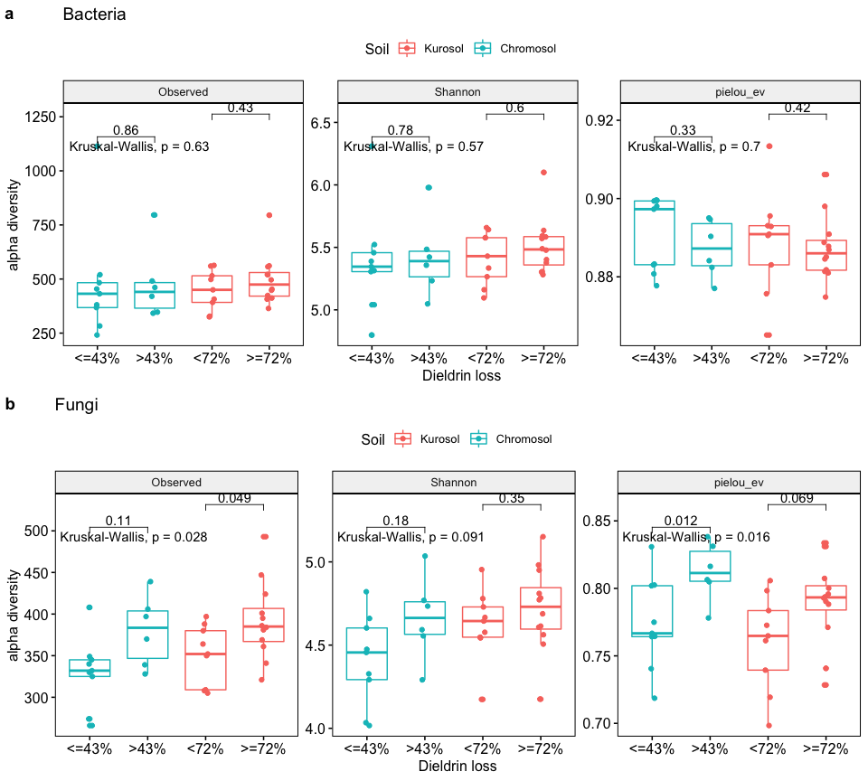

Only the fungal alpha diversity was associated with the long-term dieldrin loss (figure @ref(fig:alphadloss)b) not the bacterial diversity (figure @ref(fig:alphadloss)a). For example, fungal pielou evenness was greatest in samples that were associated with high long-term dieldrin loss. Hence in a high-loss environment, the fungal OTUs were distributed more evenely. Furthermore, the mean number of observed fungal OTUs and fungal shannon diversity was lowest in samples that had the lowest dieldrin loss.

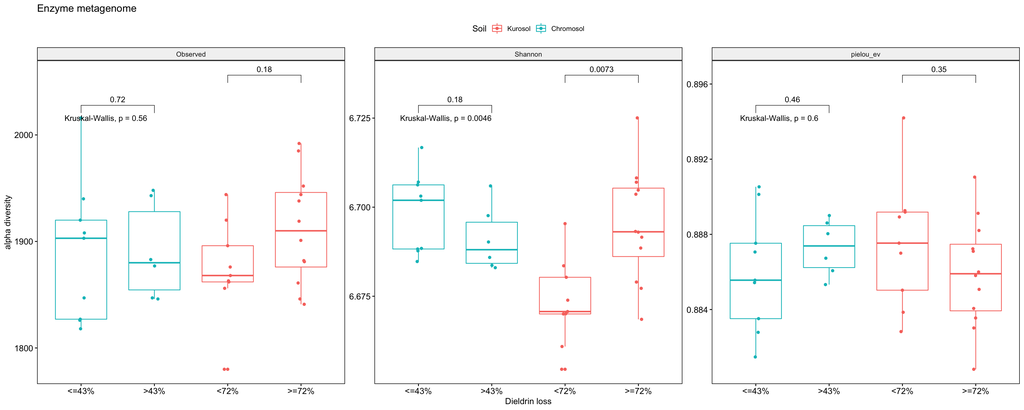

The functional diversity based on the predicted enzyme metagenome was similar across the two soils (figure @ref(fig:alphadlossenzymes)). However, in the Kurosol, the shannon diversity was greater in the high-loss samples while the number of observed enzymes and pilou evenness remained the same. Shannon’s index accounts for both abundance and evenness so an increase of this index without an increase in evenness, indicated that more enzyme were present with greater abundances.

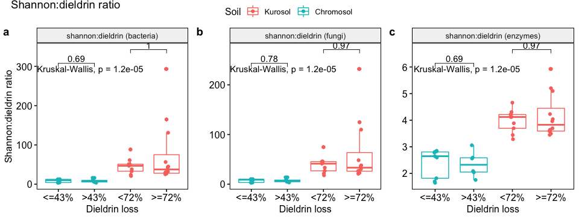

Soil diversity per unit dieldrin (µg/g) was compared (figure @ref(fig:alphaperD17)). It showed that the Chromosol, which contained more organic matter and dieldrin, had significantly lower diversity for each µg/g of dieldrin compared to the Kurosol. Hence, there was a less diverse community of bacteria, fungi and a lower diversity of functions in the ‘low-loss’ soil.

# Betadiversity

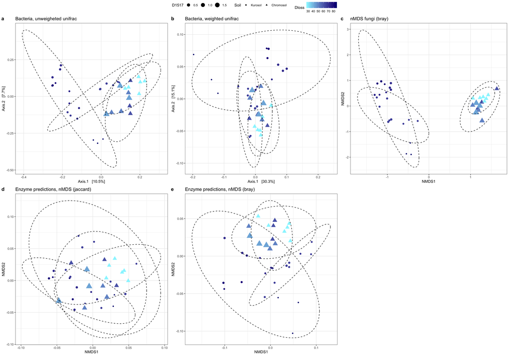

(figure @ref(fig:pcoa))